# MPDW 3 - Regresi Linier Sederhana

Abie

2025-08-28

# Persiapan

```r
library(TTR)
library(lmtest)
library(dplyr)
library(readxl)
library(forecast)
library(orcutt)
library(HoRM)
```

```r
library(ggplot2)
```

# Data Bojonegoro

```r
# Input Data
bjn <- read_xlsx("C:/Users/Abie/OneDrive/Documents/5/mpdw/ipm bojonegoro.xlsx")
bjn
```

```
## # A tibble: 15 × 2
##    tahun   ipm
##    <dbl> <dbl>
##  1  2010  62.2
##  2  2011  63.2
##  3  2012  64.2
##  4  2013  64.8
##  5  2014  65.3
##  6  2015  66.2
##  7  2016  66.7
##  8  2017  67.3
##  9  2018  67.8
## 10  2019  68.8
## 11  2020  69.0
## 12  2021  69.6
## 13  2022  70.1
## 14  2023  70.8
## 15  2024  71.8
```

```r
# Konversi ke time series
bjngr<-ts(bjn$ipm, start=2010)
bjngr
```

```
## Time Series:
## Start = 2010
## End = 2024
## Frequency = 1
##  [1] 62.19 63.22 64.20 64.85 65.27 66.17 66.73 67.28 67.85 68.75 69.04 69.59
## [13] 70.12 70.85 71.78
```

# Eksplorasi data

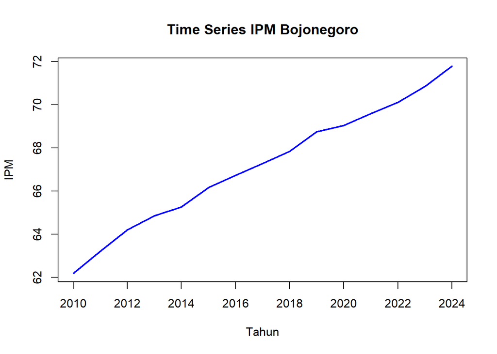

```r
# Plot time series
ts.plot(bjngr, main="Time Series IPM Bojonegoro", ylab="IPM", xlab="Tahun", col="blue", lwd=2)
```

Dari plot di atas, terlihat bahwa IPM Bojonegoro menunjukkan tren meningkat dari tahun 2010 hingga 2024. Secara keseluruhan, tren jangka panjang menunjukkan peningkatan yang konsisten dalam IPM Bojonegoro selama periode tersebut sehingga pola dari data ini adalah pola tren. Untuk itu, selanjutnya akan dilakukan ramalan dan pemulusan dengan metode DMA dan DES karena terlihat pada plot di atas

## DMA

```r
bjngr.sma <- SMA(bjngr, n=3)
dma <- SMA(bjngr.sma, n=3)
At <- 2*bjngr.sma - dma
Bt <- 2/(3-1)*(bjngr.sma - dma)
bjngr.dma<- At+Bt
bjngr.ramal<- c(NA, bjngr.dma)

t = 1:5
f = c()

for (i in t) {
  f[i] = At[length(At)] + Bt[length(Bt)]*(i)
}
```

```r
bjngr.gab <- cbind(aktual = c(bjngr,rep(NA,5)),
                pemulusan1 = c(bjngr.sma,rep(NA,5)),
                pemulusan2 = c(bjngr.dma, rep(NA,5)),
                At = c(At, rep(NA,5)),
                Bt = c(Bt,rep(NA,5)),
                ramalan = c(bjngr.ramal, f[-1]))
bjngr.gab
```

```
##       aktual pemulusan1 pemulusan2       At        Bt  ramalan
##  [1,]  62.19         NA         NA       NA        NA       NA
##  [2,]  63.22         NA         NA       NA        NA       NA
##  [3,]  64.20   63.20333         NA       NA        NA       NA
##  [4,]  64.85   64.09000         NA       NA        NA       NA
##  [5,]  65.27   64.77333   66.27556 65.52444 0.7511111       NA
##  [6,]  66.17   65.43000   66.76111 66.09556 0.6655556 66.27556
##  [7,]  66.73   66.05667   67.33000 66.69333 0.6366667 66.76111
##  [8,]  67.28   66.72667   68.03778 67.38222 0.6555556 67.33000
##  [9,]  67.85   67.28667   68.48000 67.88333 0.5966667 68.03778
## [10,]  68.75   67.96000   69.23111 68.59556 0.6355556 68.48000
## [11,]  69.04   68.54667   69.77778 69.16222 0.6155556 69.23111
## [12,]  69.59   69.12667   70.29111 69.70889 0.5822222 69.77778
## [13,]  70.12   69.58333   70.57889 70.08111 0.4977778 70.29111
## [14,]  70.85   70.18667   71.29556 70.74111 0.5544444 70.57889
## [15,]  71.78   70.91667   72.29222 71.60444 0.6877778 71.29556
## [16,]     NA         NA         NA       NA        NA 72.29222
## [17,]     NA         NA         NA       NA        NA 72.98000
## [18,]     NA         NA         NA       NA        NA 73.66778
## [19,]     NA         NA         NA       NA        NA 74.35556
## [20,]     NA         NA         NA       NA        NA 75.04333
```

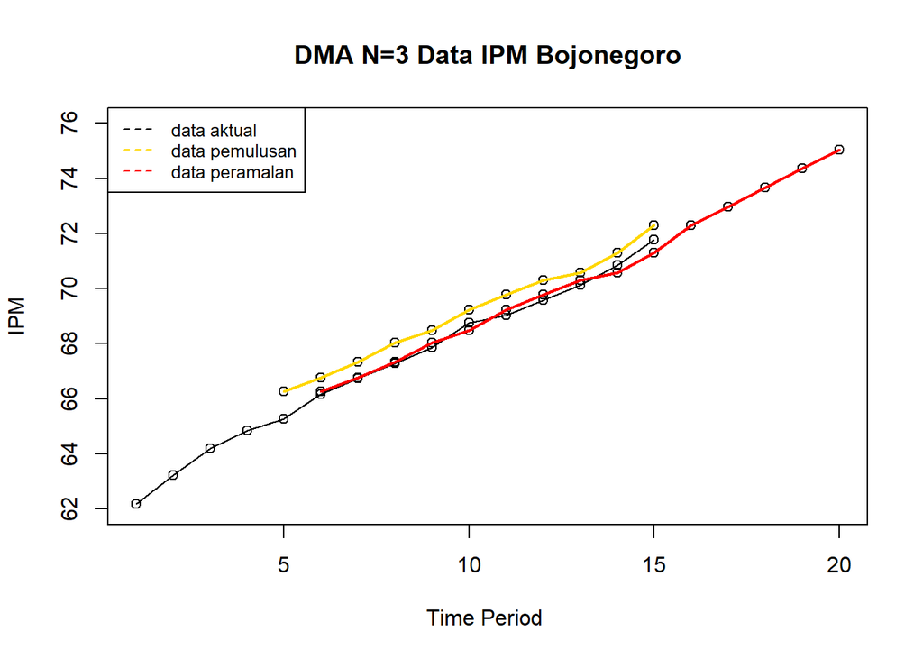

```r
#Plot time series
ts.plot(bjngr.gab[,1], xlab="Time Period ", ylab="IPM",
        main= "DMA N=3 Data IPM Bojonegoro", ylim=c(62,76))
points(bjngr.gab[,1])
points(bjngr.gab[,3])
points(bjngr.gab[,6])
lines(bjngr.gab[,3],col="gold",lwd=2)
lines(bjngr.gab[,6],col="red",lwd=2)
legend("topleft",c("data aktual","data pemulusan","data peramalan"),
       lty=8, col=c("black","gold","red"), cex=0.8)
```

Dari plot di atas, terlihat bahwa metode DMA dengan N=3 memberikan hasil pemulusan yang cukup baik dalam mengikuti tren data IPM Bojonegoro. Garis pemulusan (warna emas) mendekati data aktual (warna hitam) dengan fluktuasi yang lebih halus. Selain itu, peramalan (warna merah) menunjukkan tren kenaikan yang konsisten, sesuai dengan pola data historis. Hal ini menunjukkan bahwa metode DMA memberikan prediksi yang masuk akal untuk periode mendatang.

```r
#Menghitung nilai keakuratan
error.dma = bjngr-bjngr.ramal[1:length(bjngr)]
SSE.dma = sum(error.dma[6:length(bjngr)]^2)
MSE.dma = mean(error.dma[6:length(bjngr)]^2)
MAPE.dma = mean(abs((error.dma[6:length(bjngr)]/bjngr[6:length(bjngr)])*100))

akurasi.dma <- matrix(c(SSE.dma, MSE.dma, MAPE.dma))
row.names(akurasi.dma)<- c("SSE", "MSE", "MAPE")
colnames(akurasi.dma) <- c("Akurasi m = 3")
akurasi.dma
```

```
##      Akurasi m = 3
## SSE      0.5320210
## MSE      0.0532021
## MAPE     0.2798171
```

## DES

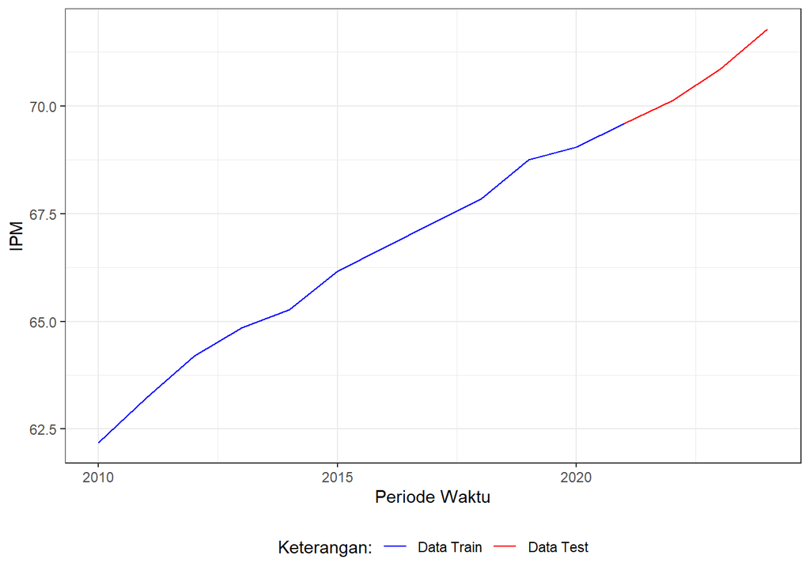

```r
#membagi training dan testing (80:20)
training<-bjn[1:12,]
testing<-bjn[12:15,]

#data time series
training.ts<-ts(training[,2])
testing.ts<-ts(testing[,2],start=11)

#eksplorasi data
ggplot() +
  geom_line(data = training, aes(x = tahun, y = ipm, col = "Data Train")) +
  geom_line(data = testing, aes(x = tahun, y = ipm, col = "Data Test")) +
  labs(x = "Periode Waktu", y = "IPM", color = "Legend") +
   scale_colour_manual(name="Keterangan:", breaks = c("Data Train", "Data Test"),
                      values = c("blue", "red")) +
  theme_bw() + theme(legend.position = "bottom",
                     plot.caption = element_text(hjust=0.5, size=12))
```

```r
des.opt<- HoltWinters(training.ts, gamma = FALSE)
des.opt
```

```
## Holt-Winters exponential smoothing with trend and without seasonal component.
##
## Call:
## HoltWinters(x = training.ts, gamma = FALSE)
##
## Smoothing parameters:
##  alpha: 0.6990977
##  beta : 0.708413
##  gamma: FALSE
##
## Coefficients:
##         [,1]
## a 69.6225209
## b  0.5033102
```

Didapatkan nilai alpha optimal sebesar 0.699 dan beta sebesar 0.708.

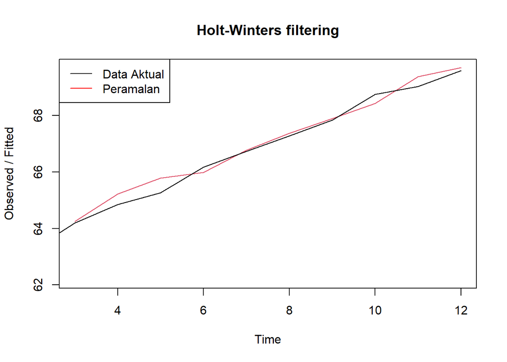

```r
plot(des.opt)
legend("topleft", c("Data Aktual", "Peramalan"), col = c("black", "red"),
       lty = c(1,1))
```

```r
#ramalan
ramalandesopt<- forecast(des.opt, h=5)
ramalandesopt
```

```
##    Point Forecast    Lo 80    Hi 80    Lo 95    Hi 95
## 13       70.12583 69.80506 70.44660 69.63526 70.61640
## 14       70.62914 70.12948 71.12880 69.86497 71.39331
## 15       71.13245 70.39530 71.86960 70.00508 72.25983
## 16       71.63576 70.61863 72.65289 70.08020 73.19133
## 17       72.13907 70.80730 73.47084 70.10230 74.17584
```

```r
#Menghitung nilai keakuratan
#data training
ssedes.train<-des.opt$SSE
msedes.train<-ssedes.train/length(training.ts)
sisaandes<-ramalandesopt$residuals
head(sisaandes)
```

```
## Time Series:
## Start = 1
## End = 6
## Frequency = 1
##               x
## [1,]         NA
## [2,]         NA
## [3,] -0.0500000
## [4,] -0.3702826
## [5,] -0.5132740
## [6,]  0.1778984
```

```r
mapedes.train <- sum(abs(sisaandes[3:length(training.ts)]/training.ts[3:length(training.ts)])*100)/length(training.ts[3:12])

akurasides.opt <- matrix(c(ssedes.train,msedes.train,mapedes.train))
row.names(akurasides.opt)<- c("SSE", "MSE", "MAPE")
colnames(akurasides.opt) <- c("Akurasi lamda dan gamma optimum")
akurasides.opt
```

```
##      Akurasi lamda dan gamma optimum
## SSE                       0.67693272
## MSE                       0.05641106
## MAPE                      0.30915863
```

```r
#data testing
selisihdesopt<-ramalandesopt$mean-testing.ts
selisihdesopt
```

```
## Time Series:
## Start = 13
## End = 14
## Frequency = 1
##      testing.ts
## [1,] -0.7241689
## [2,] -1.1508588
```

```r
SSEtestingdesopt<-sum(selisihdesopt^2)
SSEtestingdesopt<-SSEtestingdesopt/length(testing.ts)
MAPEtestingdesopt<-sum(abs(selisihdesopt/testing.ts)*100)/length(testing.ts)

akurasiDesTesting <- matrix(c(SSEtestingdesopt,SSEtestingdesopt,MAPEtestingdesopt))
row.names(akurasiDesTesting)<- c("SSE", "MSE", "MAPE")
colnames(akurasiDesTesting) <- c("Akurasi lamda dan gamma optimum")
akurasiDesTesting
```

```
##      Akurasi lamda dan gamma optimum
## SSE                        0.4622241
## MSE                        0.4622241
## MAPE                       0.6563574
```

```r
#perbandingan akurasi
cbind(akurasi.dma, akurasides.opt)
```

```
##      Akurasi m = 3 Akurasi lamda dan gamma optimum
## SSE      0.5320210                      0.67693272
## MSE      0.0532021                      0.05641106
## MAPE     0.2798171                      0.30915863
```

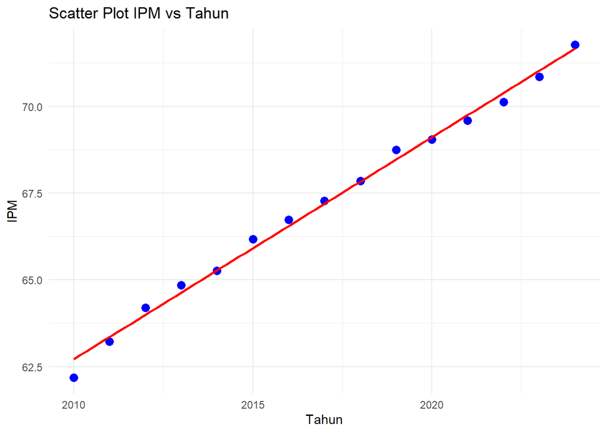

```r
#scatter plot ipm vs tahun
ggplot(bjn, aes(x = tahun, y = ipm)) +
  geom_point(color = "blue", size = 3) +
  geom_smooth(method = "lm", color = "red", se = FALSE) +
  labs(title = "Scatter Plot IPM vs Tahun",
       x = "Tahun",
       y = "IPM") +
  theme_minimal()
```

```r
#korelasi
cor(bjn$tahun, bjn$ipm)
```

```
## [1] 0.996895
```

terlihat jelas terdapat korelasi positif antara tahun dan ipm dengan nilai korelasi sebesar 0.996, sehingga akan dilakukan regresi linier sederhana.

# Regresi Linier Sederhana

```r
regbjn <- lm(ipm ~ tahun, data = bjn)
summary(regbjn)
```

```
##
## Call:
## lm(formula = ipm ~ tahun, data = bjn)
##
## Residuals:
##      Min       1Q   Median       3Q      Max
## -0.52617 -0.14817  0.01783  0.19083  0.27833
##
## Coefficients:
##               Estimate Std. Error t value Pr(>|t|)
## (Intercept) -1.223e+03  2.826e+01  -43.27 1.94e-15 ***
## tahun        6.395e-01  1.401e-02   45.65 9.74e-16 ***
## ---
## Signif. codes:  0 '***' 0.001 '**' 0.01 '*' 0.05 '.' 0.1 ' ' 1
##
## Residual standard error: 0.2344 on 13 degrees of freedom
## Multiple R-squared:  0.9938, Adjusted R-squared:  0.9933
## F-statistic:  2084 on 1 and 13 DF,  p-value: 9.739e-16
```

model yang dihasilkan:
$$y_i = -1223 + 0.639x_i$$
Hasil uji F menunjukkan p-value < 0.05, begitu juga uji t pada intersep dan penduga yang menunjukkan nilai p-value < 0.05 artinya model ini signifikan pada taraf nyata 5% dengan $R^2$ = 0.9938 yang berarti sebesar 99.38% keragaman IPM dapat dijelaskan oleh nilai peubah tahun. Setelah ini akan diperiksa asumsi-asumsi yang diperlukan

# Uji Asumsi Grafik

## Homokedastisitas

### Grafik residual vs fitted

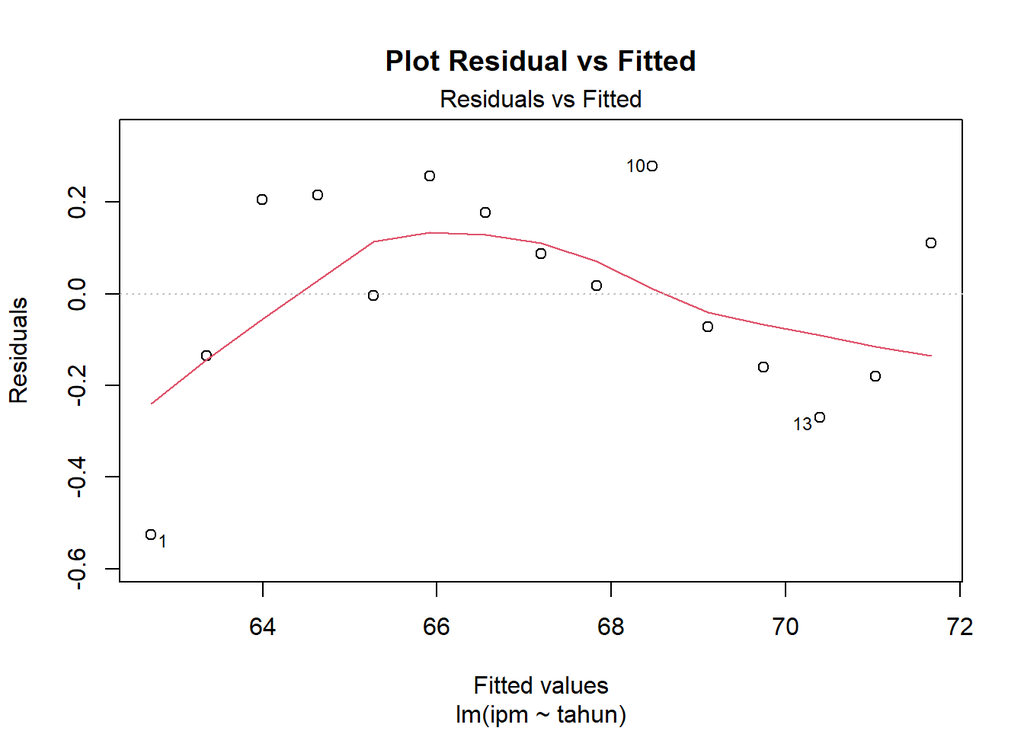

```r
plot(regbjn, 1, main = "Plot Residual vs Fitted")
```

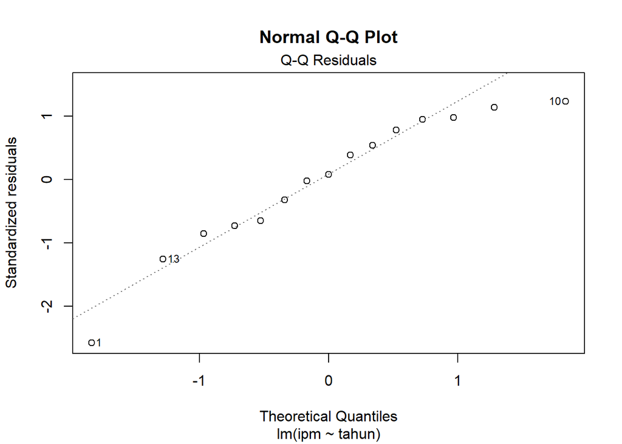

```r
plot(regbjn, 2, main = "Normal Q-Q Plot")
```

## Autokorelasi

### Grafik residual vs order

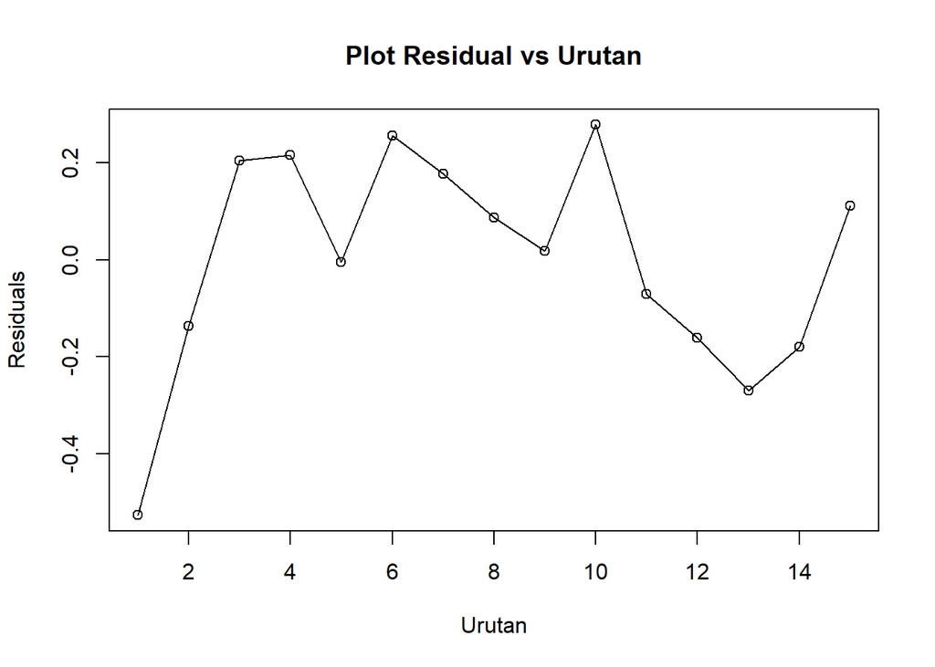

```r
plot(residuals(regbjn), type = "o", main = "Plot Residual vs Urutan", xlab = "Urutan", ylab = "Residuals")
```

### plot acf

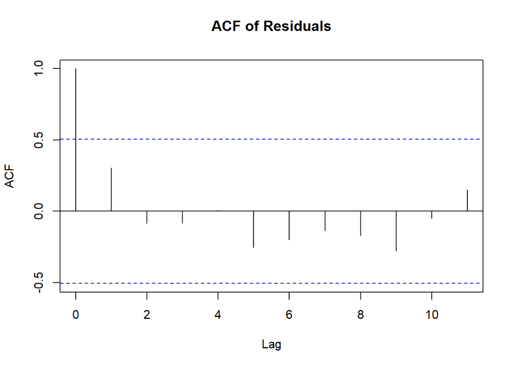

```r
acf(residuals(regbjn), main = "ACF of Residuals")
```

### pacf

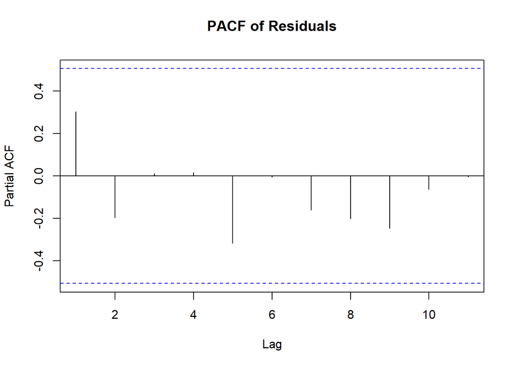

```r
pacf(residuals(regbjn), main = "PACF of Residuals")
```

# Uji Asumsi Statistik

## Uji Normalitas

```r
shapiro.test(residuals(regbjn))
```

```
##
##  Shapiro-Wilk normality test
##
## data:  residuals(regbjn)
## W = 0.93636, p-value = 0.3388
```

## Uji Homokedastisitas

```r
bptest(regbjn)
```

```
##
##  studentized Breusch-Pagan test
##
## data:  regbjn
## BP = 2.3329, df = 1, p-value = 0.1267
```

## Uji Autokorelasi

```r
dwtest(regbjn)
```

```
##
##  Durbin-Watson test
##
## data:  regbjn
## DW = 0.98868, p-value = 0.005666
## alternative hypothesis: true autocorrelation is greater than 0
```

Terdapat pelanggaran pada asumsi autokorelasi, artinya sisaan menunjukkan korelasi dengan sisaan pada periode sebelumnya. Oleh karena itu, akan dilakukan regresi ulang dengan metode Cochrane-Orcutt dan Hildreth-Lu

# Regresi Cochrane-Orcutt

```r
regbjn.co <- cochrane.orcutt(regbjn)
regbjn.co
```

```
## Cochrane-orcutt estimation for first order autocorrelation
##
## Call:
## lm(formula = ipm ~ tahun, data = bjn)
##
##  number of interaction: 12
##  rho 0.295658
##
## Durbin-Watson statistic
## (original):    0.98868 , p-value: 5.666e-03
## (transformed): 2.10085 , p-value: 4.481e-01
##
##  coefficients:
##  (Intercept)        tahun
## -1176.020935     0.616406
```

```r
rho = regbjn.co$rho
```

Output model yang dihasilkan adalah:
$$y_i=-1176.02+0.616x_i$$
nilai p-value > 0.05, artinya belum cukup bukti menyatakan bahwa sisaan terdapat autokorelasi pada taraf nyata 5%. Untuk nilai $\rho$ optimum yang digunakan adalah 0.2956.

Selanjutnya akan dilakukan transformasi secara manual

```r
ipm.trans <- bjn$ipm[-1]-rho*bjn$ipm[-length(bjn$ipm)]
tahun.trans <- bjn$tahun[-1]-rho*bjn$tahun[-length(bjn$tahun)]
modelCOmanual <- lm(ipm.trans~tahun.trans)
summary(modelCOmanual)
```

```
##
## Call:
## lm(formula = ipm.trans ~ tahun.trans)
##
## Residuals:
##      Min       1Q   Median       3Q      Max
## -0.18939 -0.12497 -0.02639  0.09708  0.25754
##
## Coefficients:
##               Estimate Std. Error t value Pr(>|t|)
## (Intercept) -828.32146   20.73737  -39.94 3.92e-14 ***
## tahun.trans    0.61641    0.01459   42.25 2.01e-14 ***
## ---
## Signif. codes:  0 '***' 0.001 '**' 0.01 '*' 0.05 '.' 0.1 ' ' 1
##
## Residual standard error: 0.155 on 12 degrees of freedom
## Multiple R-squared:  0.9933, Adjusted R-squared:  0.9928
## F-statistic:  1785 on 1 and 12 DF,  p-value: 2.007e-14
```

```r
b0.co <- coef(modelCOmanual)[1]/(1-rho)
b1.co <- coef(modelCOmanual)[2]
b0.co
```

```
## (Intercept)
##   -1176.021
```

```r
b1.co
```

```
## tahun.trans
##   0.6164063
```

model regresi sudah sesuai dengan regbjn cochrane-orcutt dengan packages.

# Regresi Hildreth-Lu

```r
hildreth.lu.func<- function(r, model){
  x <- model.matrix(regbjn)[,-1]
  y <- model.response(model.frame(model))
  n <- length(y)
  t <- 2:n
  y <- y[t]-r*y[t-1]
  x <- x[t]-r*x[t-1]

  return(lm(y~x))
}

#Pencariab rho yang meminimumkan SSE
r <- c(seq(0.1,0.9, by= 0.1))
tab <- data.frame("rho" = r, "SSE" = sapply(r, function(i){deviance(hildreth.lu.func(i, regbjn))}))
round(tab, 4)
```

```
##   rho    SSE
## 1 0.1 0.3150
## 2 0.2 0.2947
## 3 0.3 0.2883
## 4 0.4 0.2959
## 5 0.5 0.3175
## 6 0.6 0.3530
## 7 0.7 0.4025
## 8 0.8 0.4659
## 9 0.9 0.5433
```

SSE minimum pada rentang 0.2 - 0.3 sehingga akan dicari lagi pada rentang tersebut dengan interval 0.001.

```r
rOpt <- seq(0.2,0.3, by= 0.001)
tabOpt <- data.frame("rho" = rOpt, "SSE" = sapply(rOpt, function(i){deviance(hildreth.lu.func(i, regbjn))}))
head(tabOpt[order(tabOpt$SSE),])
```

```
##      rho       SSE
## 97 0.296 0.2883105
## 96 0.295 0.2883107
## 98 0.297 0.2883117
## 95 0.294 0.2883124
## 99 0.298 0.2883143
## 94 0.293 0.2883154
```

SSE minimum terlihat pada $\rho=0.296$. Akan dilihat pada grafik berikut

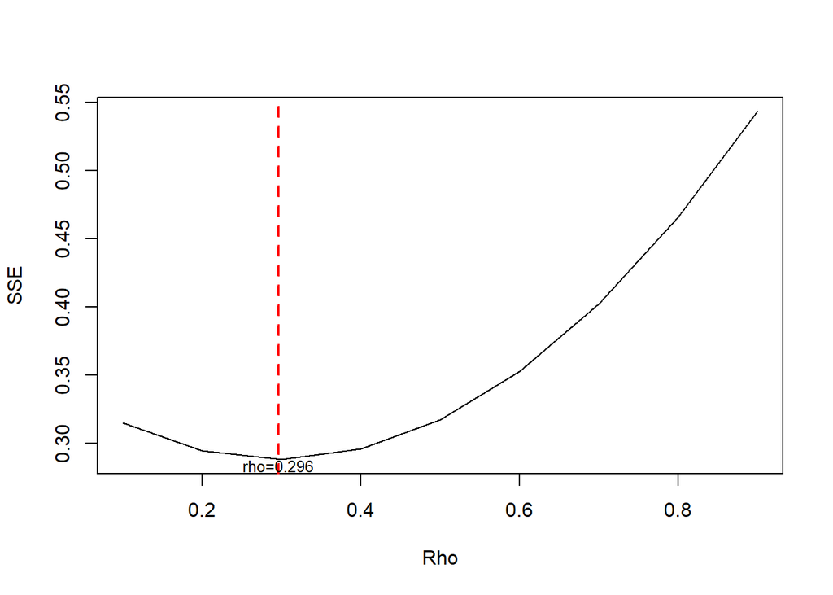

```r
par(mfrow = c(1,1))
plot(tab$SSE ~ tab$rho , type = "l", xlab = "Rho", ylab = "SSE")
abline(v = tabOpt[tabOpt$SSE==min(tabOpt$SSE),"rho"], lty = 2, col="red",lwd=2)
text(x=0.296, y=0.284, labels = "rho=0.296", cex = 0.8)
```

Hasil perhitungan dan grafik menunjukan hasil yang konsisten dengan nilai $\rho$ optimum sebesar 0.296. Selanjutnya, model dapat didapatkan dengan mengevaluasi nilai $\rho$ ke dalam fungsi hildreth.lu, serta dilanjutkan dengan pengujian autokorelasi dengan uji Durbin-Watson. Namun, setelah pengecekan tersebut tidak lupa koefisien regresi tersebut digunakan untuk transformasi balik. Persamaan hasil transformasi itulah yang menjadi persamaan sesungguhnya.

```r
modelHL <- hildreth.lu.func(0.296, regbjn)
summary(modelHL)
```

```
##
## Call:
## lm(formula = y ~ x)
##
## Residuals:
##      Min       1Q   Median       3Q      Max
## -0.18935 -0.12483 -0.02644  0.09710  0.25753
##
## Coefficients:
##              Estimate Std. Error t value Pr(>|t|)
## (Intercept) -827.9053    20.7374  -39.92 3.94e-14 ***
## x              0.6164     0.0146   42.23 2.02e-14 ***
## ---
## Signif. codes:  0 '***' 0.001 '**' 0.01 '*' 0.05 '.' 0.1 ' ' 1
##
## Residual standard error: 0.155 on 12 degrees of freedom
## Multiple R-squared:  0.9933, Adjusted R-squared:  0.9928
## F-statistic:  1783 on 1 and 12 DF,  p-value: 2.019e-14
```

```r
dwtest(modelHL)
```

```
##
##  Durbin-Watson test
##
## data:  modelHL
## DW = 2.1012, p-value = 0.4484
## alternative hypothesis: true autocorrelation is greater than 0
```

Hasil pada model Hidreth-Lu menunjukkan p-value > 0.05, artinya belum cukup bukti menyatakan bahwa sisaan terdapat autokorelasi pada taraf nyata 5% sehingga asumsi amatan saling bebas terpenuhi.

```r
cat("y = ", coef(modelHL)[1]/(1-0.341), "+", coef(modelHL)[2],"x", sep = "")
```

```
## y = -1256.305+0.6163969x
```

# Kesimpulan

Berdasarkan hasil analisis regresi linier sederhana pada data IPM Bojonegoro, diperoleh model regresi yang masih melanggar asumsi autokorelasi sehingga perlu ditangani dengan metode Cochrane-Orcutt dan Hidrathe-Lu. Hasil kedua metode tersebut sudah tidak lagi melanggar asumsi adanya autokorelasi sehingga model regresinya valid.

Adapun perbandingan antara ketiga metode tersebut sebagai berikut:

```r
ssemodelawal <- anova(regbjn)$`Sum Sq`[-1]
ssemodelCO <- anova(modelCOmanual)$`Sum Sq`[-1]
ssemodelHL <- anova(modelHL)$`Sum Sq`[-1]
msemodelawal <- ssemodelawal/length(bjn$ipm)
msemodelCO <- ssemodelCO/length(bjn$ipm)
msemodelHL <- ssemodelHL/length(bjn$ipm)
akurasi <- matrix(c(ssemodelawal,msemodelawal,ssemodelCO,msemodelCO,ssemodelHL,
                    msemodelHL),nrow=3,ncol=2,byrow = T)
colnames(akurasi) <- c("SSE","MSE")
row.names(akurasi) <- c("model Awal", "model Cochrane-Orcutt", "model Hildreth-Lu")
akurasi
```

```
##                             SSE        MSE
## model Awal            0.7144233 0.04762822
## model Cochrane-Orcutt 0.2883104 0.01922070
## model Hildreth-Lu     0.2883105 0.01922070
```

Dari hasil di atas, terlihat bahwa metode Cochrane-Orcutt dan Hildreth-Lu memberikan hasil yang lebih baik dibandingkan model awal, dengan nilai SSE dan MSE yang lebih rendah. Hal ini menunjukkan bahwa penanganan autokorelasi pada model regresi linier sederhana dapat meningkatkan akurasi model dalam menjelaskan variabilitas data IPM Bojonegoro.